# Introdução a dataviz no R

Euler Alencar

31/01/2022

# Intro Data Viz

Ggplot é chamado de gramática dos gráficos. Há sete elementos nessa gramática. Imagine uma frase. Cada parte tem sua função gramatical que pretende transmitir uma determinada mensagem.

No livro The Grammar of Graphics, Leland Wilkinson, traz dois princípios:

- Gráficos são construídos por distintas camadas de elementos gráficos;
- Insights significativos são construídos com ‘aesthetic mapping’

Há 7 elementos dessa gramática visual:

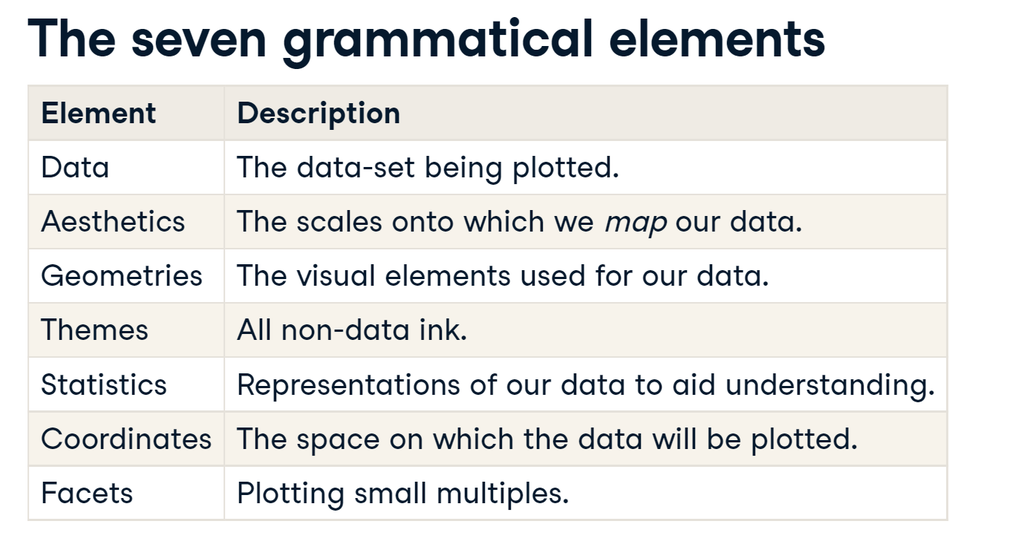

O jargão de cada elemento pode ser visto abaixo:

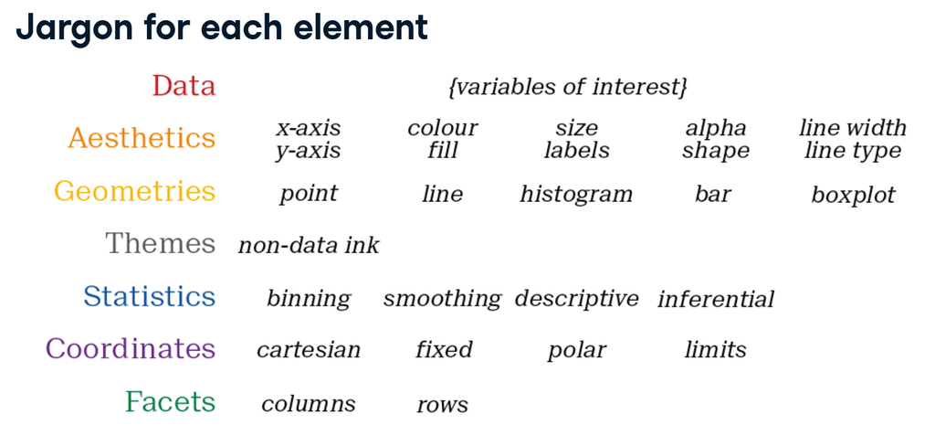

Para este curso vamos considerar os seguintes elementos:

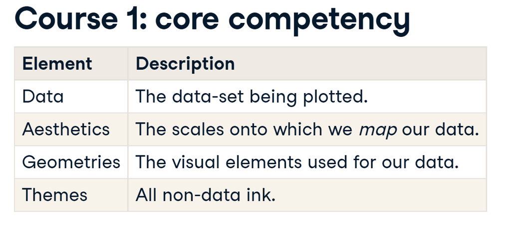